# ЕГЭ 2018 Вариант 12 EGE 2018 Variant 12

Использованы материалы:

The list of used links and books:

[ЕГЭ 2018. Математика. Профильный уровень. 20 вариантов тестов. Тематическая рабочая тетрадь.](https://drive.google.com/file/d/0B8CJrELbJAyodmtvbV8xcEtZXzA/view)

[SymPy Tutorials](http://nbviewer.jupyter.org/url/www.inp.nsk.su/~grozin/python/sympy.ipynb)

[LaTeX Mathematics](https://en.wikibooks.org/wiki/LaTeX/Mathematics)

```python
%%html
<style>
@import url('https://fonts.googleapis.com/css?family=Roboto&effect=3d|scuffed-steel|static|canvas-print|');
a, h1 h2, h3, h4, div.text_cell_render {font-family: 'Roboto'; text-shadow: 4px 4px 4px #aaa;}

h2, h3, div.output_prompt, div.output_area pre {color: slategray;}
h1, h4, div.input_prompt {color: steelblue;}
a, div.output_subarea {color: darkblue;}

span {text-shadow: 4px 4px 4px #aaa;}

body, div.output_stderr pre{background-color: aliceblue;}
div.output_stderr {background-color: slategray;}
</style>
```

```python
import numpy
import pandas
import math

import networkx as nx
import prettyplotlib as ppl

import matplotlib.pyplot as plt
import matplotlib.patches as pat
from mpl_toolkits.mplot3d import Axes3D
from mpl_toolkits.mplot3d.art3d import Poly3DCollection, Line3DCollection
import matplotlib
%matplotlib inline
```

```python
import sympy
from sympy import *
from sympy import init_printing
init_printing()
```

```python
answer_dictionary = dict()
```

## Часть 1 Part 1

[figure not shown]

### Задание 1 / Task 1

В туристический поход на 7 дней отправляется группа из 8 человек. В походе на одного человека приходится 90 граммов сахара в день.

Сколько трёхкилограммовых мешков сахара нужно купить, чтобы сахара хватило на всеь поход?

A group of 8 people is sent to the tourist tour for 7 days. For one person, it needs 90 grams of sugar per day.

How many three-kilogram bags of sugar do they need to buy to have enough sugar for the whole trip?

$7 * 8 * 90 \ грамм = 5040 \ грамм$ - необходимый запас для 8 человек на 7 дней.

Для того, чтобы сахара гарантированно хватило, необходимо $2 * 3 \ килограмма = 2 * 3000 \ грамм = 6000 \ грамм$.

$7 * 8 * 90 \ grams = 5040 \ grams$ - necessary stock for 8 people for 7 days.

In order that sugar is enough for this period, it needs $2 * 3 \ kilograms = 2 * 3000 \ grams = 6000 \ grams$.

$3000 < 5040 < 6000$

### Ответ / Answer: 2

```python
answer_dictionary[1]=str(math.ceil(7 * 8 * 90 / 3000))
```

[figure not shown]

### Задание 2 / Task 2

На рисунке жирными точками показано суточное количество осадков, выпавших в Якутске с 18 по 29 октября 1986 года. По горизонтали указываются числа месяца, по вертикали - количество осадков, выпавших в соответствующий день, в миллиметрах. Для наглядности жирные точки на рисунке соединены линией.

Определите по рисунку, какого числа за данный период выпало наибольшее количество осадков.

In the figure, the daily amount of precipitation that fell in Yakutsk from October 18 to October 29, 1986, was marked by large dots. Horizontally, the numbers of the month are indicated, along the vertical line - the amount of precipitation falling on the corresponding day, in millimeters. For clarity, the dots in the figure are connected by a line.

Determine the number in the given period when the greatest amount of precipitation fell.

### Ответ / Answer: 23

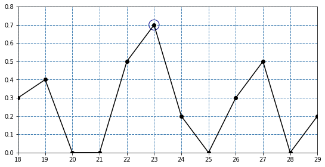

```python
f = plt.figure(figsize=(9,4.5))
ax = f.add_subplot(1,1,1)
ax.grid(c='steelblue', ls='--', lw=1)

plt.xlim(18,29)
plt.ylim(0.0,0.8)
plt.xticks(numpy.arange(18, 30, step=1))
plt.yticks(numpy.arange(0.0, 0.9, step=0.1))

ax.plot(numpy.arange(18, 30, step=1),
        [0.3,0.4,0.0,0.0,0.5,0.7,0.2,0.0,0.3,0.5,0.0,0.2],
        '-o', c='black')
ax.scatter(23, 0.7, s=300, facecolor='none', color='darkblue');
```

```python
answer_dictionary[2]=str(23)
```

[figure not shown]

### Задание 3 / Task 3

На клетчатой бумаге нарисовано два круга. Площадь внутреннего круга равна 16.

Найдите площадь заштрихованной фигуры.

On the graph paper, two circles are drawn. The area of the inner circle is 16.

Find the area of the shaded figure.

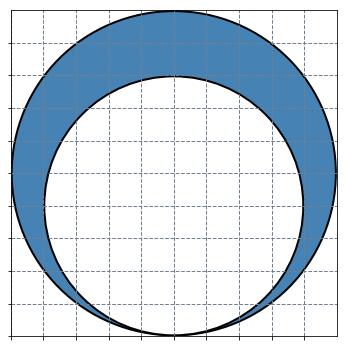

```python
f = plt.figure(figsize=(6,6))
ax = f.add_subplot(1, 1, 1, aspect=1)
ax.grid(c='slategray', ls='--', lw=1)

plt.xlim(0,10)
plt.ylim(0,10)

plt.xticks(numpy.arange(0, 10, step=1), visible=False)
plt.yticks(numpy.arange(0, 10, step=1),visible=False)

circle1 = pat.Circle((5, 5), 4.97, lw=2,
                edgecolor='black', facecolor='steelblue')
circle2 = pat.Circle((5, 4), 3.97, lw=2,
                edgecolor='black', facecolor='white')

ax.add_artist(circle1)
ax.add_artist(circle2);
```

$S_1 = 16; \ R_2 / R_1 = 5 / 4$

$S_2 = \pi * R_2^2 = \pi * R_1^2 * 25 / 16 = S_1 * 25 / 16$

$S_2 - S_1 = S_1 * 25 / 16 - S_1 = S_1 * 9 / 16 = 16 * 9 / 16 = 9$

### Ответ / Answer: 9

```python
answer_dictionary[3]=str(int(16 * 5 ** 2 / 4 ** 2 - 16))
```

[figure not shown]

### Задание 4 / Task 4

В каждой двадцать пятой банке кофе согласно условиям акции есть приз. Призы распределены по банкам случайно.

Коля покупает банку кофе в надежде выиграть приз.

Найдите вероятность того, что Коля не найдет приз в своей банке.

In every twenty-fifth jar of coffee, according to the terms of the action, there is a prize. Prizes are distributed to banks randomly.

Kolya buys a jar of coffee in the hope of winning the prize.

Find the probability that Kolya will not find a prize in his jar.

Вероятность случайного события `"найти приз в банке кофе"` равна $\large{\frac{1}{25}}$.

Вероятность противоположного события `"не найти приз в банке кофе"` равна $1 - \large{\frac{1}{25}}$ = 0.96.

The probability of a random event `"finding a prize in a jar of coffee"` is $\large{\frac{1}{25}}$.

The probability of the opposite event is `"not finding a prize in a jar of coffee"` is $1 - \large{\frac{1}{25}}$ = 0.96.

### Ответ / Answer: 0.96

```python
answer_dictionary[4]=str(24/25)
```

[figure not shown]

### Задание 5 / Task 5

Найдите корень уравнения:

Find the root of the equation:

$\log_{25}{(2 - 3 * x)} = 0.5$

### Ответ / Answer: -1

```python
%%latex
$\log_{25}{(2 - 3 * x)} = 0.5 \\
2 - 3 * x = \sqrt{25} \\
3 * x = -3 \\
x = -1$
```

$\log_{25}{(2 - 3 * x)} = 0.5 \\ 2 - 3 * x = \sqrt{25} \\ 3 * x = -3 \\ x = -1$

```python
answer_dictionary[5]=str(-1)
```

[figure not shown]

### Задание 6 / Task 6

Площадь параллелограмма равна 60, две его стороны равны 20 и 40.

Найдите большую высоту этого параллелограмма.

The area of the parallelogram is 60, its two sides are 20 and 40.

Find the larger height of this parallelogram.

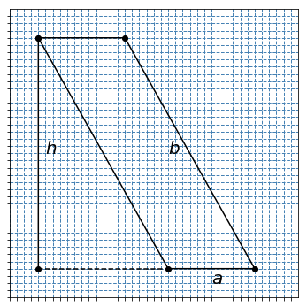

```python
f = plt.figure(figsize=(6,6))
ax = f.add_subplot(1, 1, 1, aspect=1)
ax.grid(c='steelblue', ls='--', lw=1)

ax.plot([-8,1,7,-2,-8,-8], [8,-8,-8,8,8,-8], '-o', c='black')
ax.plot([-8,1], [-8,-8], ls='--', c='black')

plt.text(-7.5,0,r'$h$', fontsize=20)
plt.text(4,-9,r'$a$', fontsize=20)
plt.text(1,0,r'$b$', fontsize=20)

plt.xlim(-10,10)
plt.ylim(-10,10)
plt.xticks(numpy.arange(-10, 10, step=0.5), visible=False)
plt.yticks(numpy.arange(-10, 10, step=0.5), visible=False);
```

Большая высота параллелограмма проведена к меньшему основанию, равному 20.

A larger height of the parallelogram corresponds to a smaller base equal to 20.

$h = S / a = 60 / 20 = 3$

### Ответ / Answer: 3

```python
answer_dictionary[6]=str(int(60/20))
```

[figure not shown]

### Задание 7 / Task 7

На рисунке изображен график функции $y = f(x)$ и отмечены точки -5, -3, 3, 7.

В какой из этих точек значение производной наибольшее? В ответе укажите эту точку.

The figure shows the graph of the function $y = f (x)$ and points -5, -3, 3, 7 are marked.

For which of these points derivative is the largest? In the answer, specify this point.

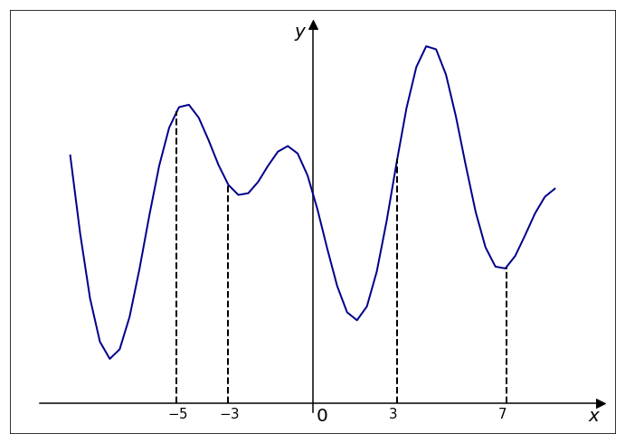

```python
f = plt.figure(figsize=(12,9))
ax = f.add_subplot(1, 1, 1, aspect=1)

ax.axhline(0, 0.05, 0.97, c='black')
ax.axvline(0, 0.05, 0.97, c='black')

def f(x,a=5,b=0.3,c=1.2,d=-4.1,e=7):
    exp = (math.pow(x, 2) + math.pow(x, 5)) * (-0.1)**5
    return a * math.exp(exp) * math.cos(b*x+d) * math.sin(c*x)+e

x = numpy.linspace(-8,8)
y = [f(el) for el in x]
ax.plot(x, y, c='darkblue', lw=2)


v = numpy.array([[-4.5,-2.8,2.8,6.4], 4*[-0.5],
                 [r'$-5$',r'$-3$',r'$3$',r'$7$']])

for el in v[0]:
    ax.plot([float(el),float(el)], [0,f(float(el))], lw=2, ls='--', c='black')

for i in range(4):
    plt.text(float(v[0][i])-0.3,float(v[1][i]),v[2][i],fontsize=15)

plt.text(9.1,-0.6,r'$x$', fontsize=20)
plt.text(-0.6,12.1,r'$y$', fontsize=20)
ax.scatter(0,12.5, marker='^', s=100, c='black')
ax.scatter(9.5,0, marker='>', s=100, c='black')
plt.text(0.1,-0.6,r'$0$', fontsize=20)

plt.xlim(-10,10)
plt.ylim(-1,13)

plt.xticks([], visible=False)
plt.yticks([], visible=False);
```

Производная положительна на тех интервалах, где функция возрастает.

Чем больше угол наклона касательной к кривой графика функции в определенной точке, тем больше значение производной функции в этой точке.

The derivative is positive at those intervals where the function increases.

The greater angle of inclination of the tangent to the curve of the function graph at a certain point means the greater value of the function derivative at this point.

### Ответ / Answer: 3

```python
answer_dictionary[7]=str(3)
```

[figure not shown]

### Задание 8 / Task 8

Через среднюю линию основания треугольной призмы, объём которой равен 32, проведена плоскость, параллельная боковому ребру.

Найдите объём отсеченной треугольной призмы.

Through the middle line of the base of the triangular prism, whose volume is 32, a plane parallel to the side edge is drawn.

Find the volume of the cut off triangular prism.

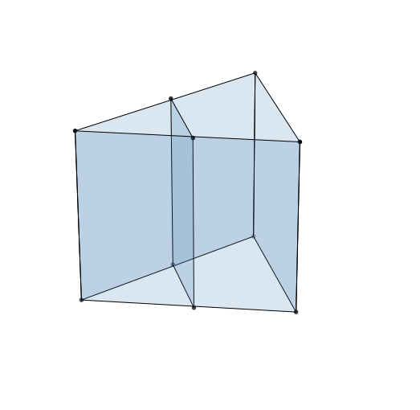

```python
f = plt.figure(figsize=(9,9))
ax = f.add_subplot(111, projection='3d')

v = numpy.array([[5,10,0], [10,5,0], [5,10,5], [10,5,5],
                 [1,1,0], [1,1,5],
                 [3,5.8,0], [5.8,3,0], [3,5.8,5], [5.8,3,5]])
ax.scatter3D(v[:, 0], v[:, 1], v[:, 2], color='black')

verts = [ [v[0],v[2],v[3],v[1]],
          [v[0],v[4],v[5],v[2]],
          [v[1],v[4],v[5],v[3]],
          [v[6],v[8],v[9],v[7]] ]

lines = Poly3DCollection(verts, lw=1, alpha=0.2,
                         edgecolors='black', facecolor='none')
lines.set_facecolor('steelblue')

ax.add_collection3d(lines)
plt.axis('off');
```

Плоскость, параллельная боковому ребру и проходящая через среднюю линию основания, пересечет другие боковые ребра и каждое из оснований также по средней линии.

Основания отсеченной призмы являются треугольниками, подобными основаниям исходной призмы. Средняя линия треугольника равна половине основания, т.е. коэффициент подобия в данном случае равен $\large{\frac {1}{2}}$. Отношение площадей подобных треугольников равно квадрату данного коэффициента.

Высота отсеченной призмы равна высоте исходной.

A plane, parallel to the lateral side and passing through the middle line of the base, intersects the other lateral sides and each of the bases also along the midline.

The bases of the clipped prism are triangles similar to the bases of the original prism. The middle line of the triangle is equal to half the base, i.е. the similarity coefficient in this case is $\large{\frac {1}{2}}$. The ratio of the areas of similar triangles is equal to the square of this coefficient.

The height of the clipped prism is equal to the height of the original prism.

$V_1 = S_1 * h_1; V_2 = S_2 * h_2$

$h_2 = h_1$; $\ S_2 = \large{\frac {S_1}{2^2}}$

$V_2 = S_2 * h_2 = \large{\frac {S_1}{2^2}}$ $ * h_1 = \large{\frac {V_1}{4}}$

$V_2 = 32 / 4 = 8$

### Ответ / Answer: 8

```python
answer_dictionary[8]=str(int(32/4))
```

[figure not shown]

### Задание 9 / Task 9

Найдите значение выражения

Find the value of the expression

$\large{\frac{(4^{\frac{4}{7}} * 7^{\frac{2}{3}})^{21}}{28^{12}}}$.

$\large{\frac{(4^{\frac{4}{7}} * 7^{\frac{2}{3}})^{21}}{28^{12}}} = \frac{4^{\frac{4 * 21}{7}} * 7^{\frac{2 * 21}{3}}}{28^{12}} = \frac{4^{12} * 7^{14}}{4^{12}* 7^{12}} =$ $7^2 = 49$

### Ответ / Answer: 49

```python
answer_dictionary[9]=str(int(round((math.pow(4,4/7) * math.pow(7,2/3)) ** 21 / 28 ** 12,0)))
```

[figure not shown]

### Задание 10 / Task 10

В розетку электросети подключены приборы, общее сопротивление которых составляет $R_1 = 88$ Ом.

Параллельно с ними в розетку предполагается подключить электрообогреватель.

Определите наименьшее возможное сопротивление $R_2$ этого электрообогревателя, если известно, что при параллельном соединении двух проводников с сопротивлениями $R_1$ и $R_2$ их общее сопротивление задаётся формулой

$R_{общ} = \large{\frac{R_1 * R_2}{R_1 + R_2}}$,

а для нормального функционирования электросети общее сопротивление в ней должно быть не меньше 24 Ом.

Ответ выразите в Омах.

In the electrical outlet, devices are connected, the total resistance of which is $R_1 = 88$ ohm.

In parallel with them in the socket it is supposed to connect an electric heater.

Determine the smallest possible resistance $R_2$ of this electric heater if it is known that when two conductors with resistances $R_1$ and $R_2$ are connected in parallel, their total resistance is given by the formula

$R_{total} = \large {\frac {R_1 * R_2} {R_1 + R_2}}$,

and for the normal operation of the electrical network, the total resistance in it must be at least 24 ohms.

Give the answer in ohms.

Обозначим r - сопротивление обогревателя, тогда общее сопротивление равно: $\large {\frac {88 * r} {88 + r}}$.

Задача сводится к решению уравнения $\large {\frac {88 * r} {88 + r}}$ = 24.

Denote by r the resistance of the heater, then the total resistance is: $\large {\frac {88 * r} {88 + r}}$. The problem reduces to solving the equation $\large {\frac {88 * r} {88 + r}}$ = 24.

### Ответ / Answer: 33

```python
r = Symbol('r')
tr = (88 * r) / (88 + r) - 24
```

```python
expand(tr)
```

$$\frac{88 r}{r + 88} - 24$$

```python
solve(tr,r)
```

$$\left [ 33\right ]$$

```python
answer_dictionary[10]=str(solve(tr,r)[0])
```

[figure not shown]

### Задание 11 / Task 11

Три килограмма черешни стоят столько же, сколько пять килограммов вишни, а три килограмма вишни - столько же, сколько два килограмма клубники.

На сколько процентов килограмм клубники дешевле килограмма черешни?

Three kilograms of sweet cherries cost as much as five kilograms of cherries, and three kilograms of cherries - as much as two kilograms of strawberries.

How much cheaper (in percentage) is a kilogram of strawberry than a kilogram of sweet cherry?

Пусть $p$ - цена килорамма черешни, тогда цена килограмма вишни равна $3 * p / 5 = 0.6 * p$, а килограмма клубники - $3 * 0.6 * p / 2 = 0.9 * p$.

Определим, насколько ниже цена клубники по сравнению с ценой черешни: $(p - 0.9 * p) / p * 100% = 10%$

### Ответ / Answer: 10

```python
answer_dictionary[11]=str(int((1 - 3/5*3/2)*100))
```

[figure not shown]

### Задание 12 / Task 12

Найдите точку максимума функции

Find the point of the function maximum

$y = - \large{\frac{1}{3}}$$* \ x * \sqrt{x} + 4 * x + 11$

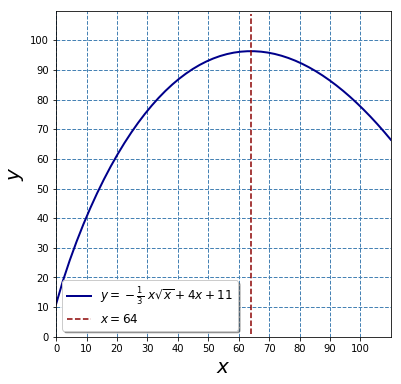

```python
f = plt.figure(figsize=(6,6))
ax = f.add_subplot(1, 1, 1)
ax.grid(c='steelblue', ls='--', lw=1)

def f(x):
    return - 1 / 3 * x * math.sqrt(x) + 4 * x + 11

x = numpy.linspace(0,110)
y = [f(el) for el in x]
ax.plot(x, y, c='darkblue', lw=2,
        label=r'$y = -\frac{1}{3}\ x \sqrt{x} + 4 x + 11$')

plt.axvline(64, 0.01, 0.99, c='darkred',
           ls='--',label=r'$x=64$')

plt.xlim(0,110)
plt.ylim(0,110)
plt.xticks(numpy.arange(0,110, step=10))
plt.yticks(numpy.arange(0,110, step=10))

plt.xlabel(r'$x$', fontsize=20)
plt.ylabel(r'$y$', fontsize=20)
plt.legend(fontsize=12, shadow=True, loc=3);
```

Наибольших значений непрерывная функция может достигать в точках, где первая производная равна нулю, а вторая производная отрицательна.

The maximum value of a continuous function can be reached at points where the first derivative is equal to zero, and the second derivative is negative.

```python
x = Symbol('x')
y = -1 / 3 * x * sqrt(x) + 4 * x + 11
```

```python
# производная | the first derivative
diff(y,x)
```

$$- 0.5 \sqrt{x} + 4$$

```python
# производная равна нулю: ∣ the first derivative is 0
solve(diff(y,x),x)
```

$$\left [ 64.0\right ]$$

```python
# вторая производная / the second derivative
diff(diff(y,x),x)
```

$$- \frac{0.25}{\sqrt{x}}$$

```python
# y''(64) < 0 => max
diff(diff(y,x),x).subs({x:64})
```

$$-0.03125$$

### Ответ / Answer: 64

```python
answer_dictionary[12]=str(64)
```

## Часть 2 Part 2

[figure not shown]

### Задание 13 / Task 13

a) Найдите корень уравнения:

a) Find the root of the equation:

$\large{\frac{3 * ctg^2 x + 4 * ctg \ x}{5 * cos^2x - 4 * cos \ x}}$ $= 0$.

б) Найдите все корни этого уравнения, принадлежащие промежутку

b) Find all the roots of this equation that belong to the interval

$[-3 * \pi; \large{\frac{-3*\pi}{2}]}$.

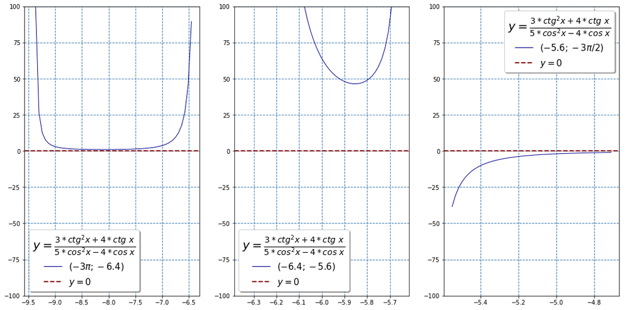

```python
f,[ax1,ax2,ax3] = plt.subplots(nrows=1,ncols=3,figsize=(18,9))

x1 = numpy.linspace(-3*math.pi,-6.45)
x2 = numpy.linspace(-6.35,-5.65)
x3 = numpy.linspace(-5.55,-3*math.pi/2)

def f(el):
    a = 3 * (math.cos(el) / math.sin(el)) ** 2 + 4 * (math.cos(el) / math.sin(el))
    b = 5 * math.cos(el) ** 2 - 4 * math.cos(el)
    return a / b

y1 = [f(el) for el in x1]
y2 = [f(el) for el in x2]
y3 = [f(el) for el in x3]

ax1.plot(x1, y1, c='darkblue', lw=1, label=r'$(-3 \pi;-6.4)$')
ax2.plot(x2, y2, c='darkblue', lw=1, label=r'$(-6.4;-5.6)$')
ax3.plot(x3, y3, c='darkblue', lw=1, label=r'$(-5.6;-3 \pi/2)$')

for p in [ax1,ax2,ax3]:
    p.grid(c='steelblue', ls='--', lw=1)
    p.set_ylim([-100,100])

    p.axhline(0, c='darkred',ls='--',lw=2,label=r'$y = 0$')

    p.legend(title=r'$y = \frac{3 * ctg^2 x + 4 * ctg \ x}{5 * cos^2x - 4 * cos \ x}}$',
             fontsize=15, shadow=True)
    p.get_legend().get_title().set_fontsize(20)
```

а)

1) Область допустимых значений / Range of admissible values

I. Для функции / For the function f(x) = ctg(x)

$x \neq \pm \pi * n, n \in \mathbb{N}$

II. Для выражения в знаменателе / For the denominator expression

$5 * cos^2x - 4 * cos \ x \neq 0$

$cos \ x \neq 0 \lor cos \ x \neq 0.8$

$x \neq \frac{\pi}{2} \pm \pi * k, k \in \mathbb{N} \; \lor x \neq \pm \arccos 0.8 \pm 2 * \pi * m, m \in \mathbb{N}$

2) Преобразования уравнения / The transformations of the equation

$3 * ctg^2 x + 4 * ctg \ x = 0$

$ctg \ x = 0 \; \lor \; ctg \ x = -\large{\frac{4}{3}} $

С учетом пункта 1) / Taking into account the point 1)

$x = arcctg\large{(-\frac{4}{3})}$$\pm 2 * \pi * t, t \in \mathbb{N}$

$x = \pi - arcctg\large{(\frac{4}{3})}$$\pm 2 * \pi * t, t \in \mathbb{N}$

б)

На интервале $[-3 * \pi; \large{\frac{-3*\pi}{2}]}$ корней нет:

On the interval $[-3 * \pi; \large{\frac{-3*\pi}{2}]}$ there are no roots:

$ -3 * \pi > -3 * \pi - arcctg\large{(\frac{4}{3})}$

$-\large{\frac{3*\pi}{2}}$$ < -\pi - arcctg$$\large{(\frac{4}{3})}$

### Ответ / Answer:

#### а) $\pi - arcctg\large{(\frac{4}{3})}$$\pm 2 * \pi * t, t \in \mathbb{N}$

#### б) на интервале $[-3 * \pi; \large{\frac{-3*\pi}{2}]}$ корней нет

```python
x = Symbol('x')
y = (3 * cot(x) * cot(x) + 4 * cot(x)) / (5 * cos(x) * cos(x) - 4 * cos(x))
```

```python
y.subs({x:-acot(4/3)}),y.subs({x:pi-acot(4/3)}),y.subs({x:2*pi-acot(4/3)}),y.subs({x:3*pi-acot(4/3)})
```

$$\left ( 0, \quad 0, \quad 0, \quad 0\right )$$

```python
y.subs({x:-4*pi-acot(4/3)}),y.subs({x:-3*pi-acot(4/3)}),y.subs({x:-2*pi-acot(4/3)}),y.subs({x:-pi-acot(4/3)})
```

$$\left ( 0, \quad 0, \quad 0, \quad 0\right )$$

```python
solve(y,x)
```

$$\left [ \right ]$$

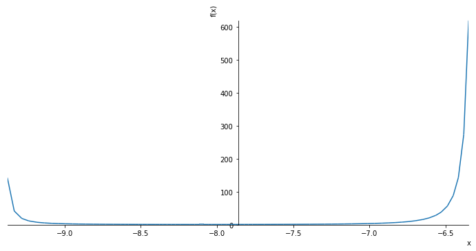

```python
plt.rcParams['figure.figsize'] = 12, 6
plot(y,(x,-3*pi+0.05,-6.35));
```

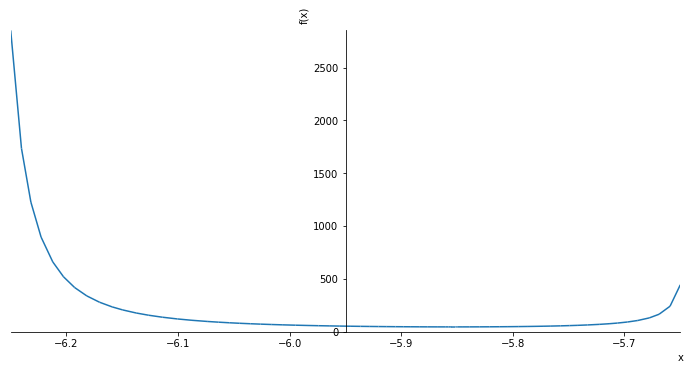

```python
plt.rcParams['figure.figsize'] = 12, 6
plot(y,(x,-6.25,-5.65));
```

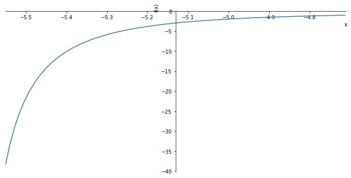

```python
plt.rcParams['figure.figsize'] = 12, 6
plot(y,(x,-5.55,-3*pi/2));
```

```python
x = Symbol('x')
y = (3 * cot(x + pi) ** 2 + 4 * cot(x + pi)) / (5 * cos(x + pi) ** 2 - 4 * cos(x + pi))
```

```python
solve(y,x)
```

$$\left [ - \operatorname{acot}{\left (\frac{4}{3} \right )}\right ]$$

```python
N(-3*pi-acot(4/3)), N(-3*pi), N(-2*pi-acot(4/3)), N(-3*pi/2), N(-pi-acot(4/3))
```

$$\left ( -10.0682790695627, \quad -9.42477796076938, \quad -6.92668641597287, \quad -4.71238898038469, \quad -3.78509376238308\right )$$

```python
answer_dictionary[13]='a) π-arcctg(4/3)±2*π∗t; t∈ℤ; б) на интервале [−3∗π;−3∗π/2] корней нет'
```

[figure not shown]

### Задание 14 / Task 14

Площадь боковой поверхности правильной четырёхугольной пирамиды SABCD равна 108,

а площадь полной поверхности этой пирамиды равна 144.

а) Постройте прямую пересечения плоскости SAC и плоскости, проходящей через вершину S этой пирамиды, середину стороны AB и центр основания.

б) Найдите площадь сечения пирамиды плоскостью SAC.

The area of the lateral surface of the regular quadrilateral pyramid SABCD is 108,

and the area of the total surface of this pyramid is 144.

a) Construct the intersection of the plane SAC and the plane passing through the vertex S of this pyramid, the middle of the side AB and the center of the base.

b) Find the cross-sectional area of the pyramid by the plane SAC.

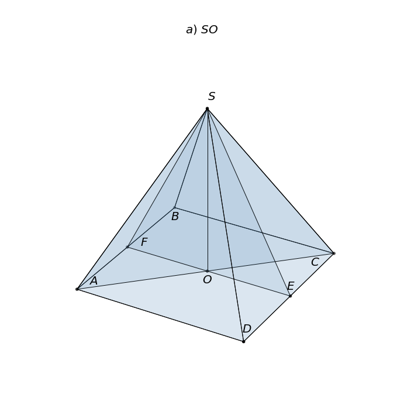

```python
f = plt.figure(figsize=(12,12))
ax = f.add_subplot(111, projection='3d')

v = numpy.array([[-1,-1,-1], [1,-1,-1], [1,1,-1],  [-1,1,-1], [0,0,1],
                 [-1,0,-1],[1,0,-1],[0,0,-1]])
ax.scatter3D(v[:, 0], v[:, 1], v[:, 2], color='black')

verts = [ [v[0],v[1],v[4]], [v[0],v[3],v[4]],
          [v[2],v[1],v[4]], [v[2],v[3],v[4]],
          [v[0],v[1],v[2],v[3]], [v[4],v[7]],
          [v[4],v[5],v[6]], [v[4],v[0],v[2]] ]

letter_xyz = numpy.array([ [0,0,1.1],[0,-0.1,-1.1],[-0.95,-0.85,-1],[-0.9,0.75,-1],
                           [0.9,0.65,-1],[0.9,-0.85,-1],[-0.9,0.1,-1],[0.9,0.1,-1] ])
letter_symbols = numpy.array([r'$S$',r'$O$',r'$A$',r'$B$',
                              r'$C$',r'$D$',r'$F$',r'$E$'])

for i in range(len(letter_xyz)):
    ax.text(letter_xyz[i][0], letter_xyz[i][1], letter_xyz[i][2],
            letter_symbols[i], color='black', fontsize=20)


piramid = Poly3DCollection(verts, lw=1, alpha=0.1,
                           edgecolors='black', facecolor='none')
piramid.set_facecolor('steelblue')
ax.add_collection3d(piramid)

plt.title(r'$a) \ SO$', fontsize=20)
plt.axis('off');
```

б)

1) $SABCD$ - правильная пирамида $\implies ABCD$ - квадрат, площадь которого равна разности площадей полной и боковой поверхностей:

$SABCD$ - a right regular pyramid $\implies ABCD$ - a square which area is equal to the difference between the areas of the full and lateral surfaces:

$\implies AB = BC = CD = AD = \sqrt{144 - 108} = 6 \implies AC = \sqrt{6^2 + 6^2} = 6 \sqrt{2}$

2) $O$ - центр основания правильной пирамиды

$O$ - a center of the base for the right regular pyramid

$\implies SO \bot OF, OF \bot AB, OF \| BC, \ OF = AB / 2 = 3$

По теореме от трех перпендикулярах:

By the theorem of three perpendiculars:

$SF \bot AB \implies SF = 2 * \large{\frac{S_{\bigtriangleup SAB}}{AB}}$$ = 2 * \large{\frac{S_{lateral \ surface}}{4 * AB} = \frac{S_{lateral \ surface}}{2 * AB} = \frac{108}{2 * 6}}$ $= 9$

3) $\bigtriangleup SFO: SO = \sqrt{SF^2 - OF^2} = \sqrt{9^2 - 3^2} = 6 * \sqrt{2}$

4) $S_{\bigtriangleup SAC} = AC * SO / 2 = 6 * \sqrt{2} * 6 * \sqrt{2} \ / \ 2 = 36$

### Ответ / Answer: 36

```python
answer_dictionary[14] = str(36)
```

[figure not shown]

### Задание 15 / Task 15

Решите неравенство:

Solve the inequality:

$1 - \large{\frac{2} {|x|} \leq \frac{23} {x^2}}$

1) Область допустимых значений: / Range of admissible values: $x \neq 0$.

2) x < 0

$1 + \large{\frac{2}{x} \leq \frac{23}{x^2}}$

$x^2 + 2 * x - 23 \leq 0$

$D = 4 - 4 * (-23) = 96$

$x = \large{\frac{ -2 \pm 4 * \sqrt{6}}{2}}$

$-1 - 2 \sqrt{6} \leq x < 0$

3) x > 0

$1 - \large{\frac{2}{x} \leq \frac{23}{x^2}}$

$x^2 - 2 * x - 23 \leq 0$

$x = \large{\frac{ 2 \pm 4 * \sqrt{6}}{2}}$

$0 < x \leq 1 + 2 \sqrt{6}$

### Ответ / Answer: $[-1-2\sqrt{6}; 0), (0; 1+2\sqrt{6}]$

```python
x = Symbol('x')
```

```python
solve(1 - 2 / abs(x) <= 23 / x ** 2)
```

$$\left(x \leq 1 + 2 \sqrt{6} \wedge 0 < x\right) \vee \left(- 2 \sqrt{6} - 1 \leq x \wedge x < 0\right)$$

```python
answer_dictionary[15]='[-1-2√6;0), (0;1+2√6]'
```

[figure not shown]

### Задание 16 / Task 16

Окружности $S_1$ и $S_2$ радиусов R и r $(R > r)$ соответственно касаются внешним образом в точке A.

Через точку B, лежащую на окружности $S_1$, проведена прямая, касающаяся окружности $S_2$ в точке M.

Известно, что $AB = a$.

а) Докажите, что расстояние от точки B до центра окружности $S_2$ равно $\sqrt{r^2 + a^2 + \large{\frac{a^2 * r}{R}}}$.

б) Найдите BM.

The circles $S_1$ and $S_2$ of the radiuses R and r $(R > r)$, respectively, touch each other externally at the point A.

Through the point B on the circle $S_1$, a line tangent to the circle $S_2$ at the point M is drawn.

It is known that $AB = a$.

a) Prove that the distance from the point B to the center of the circle $ S_2 $ is equal to $\sqrt{r^2 + a^2 + \large{\frac{a^2 * r}{R}}}$.

b) Find BM.

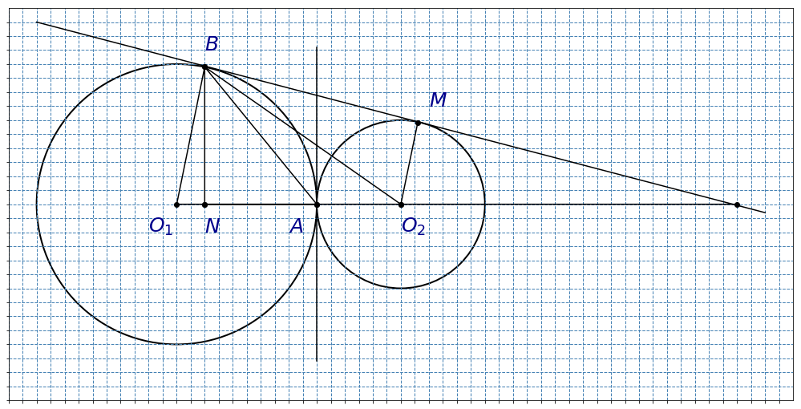

```python
f = plt.figure(figsize=(18,9))
ax = f.add_subplot(1, 1, 1, aspect=1)
ax.grid(c='steelblue', ls='--', lw=1)

circle1 = pat.Circle((-5,0),5,lw=2,
                    edgecolor='black',
                    facecolor='none')
circle2 = pat.Circle((3,0),3,lw=2,
                    edgecolor='black',
                    facecolor='none')
ax.add_artist(circle1)
ax.add_artist(circle2)

ax.plot([16,-10],[-0.3,6.5],c='black')
ax.plot([15,3,0,-4,-5,-4,-4,0,-4,3,3.6],[0,0,0,0,0,4.9,0,0,4.9,0,2.9],'-o',c='black')
plt.axvline(0,0.1,0.9,c='black')

XYL = [[-6,3,-1,-4,4,-4],
       [-1,-1,-1,5.5,3.5,-1],
       [r'$O_1$',r'$O_2$',r'$A$',r'$B$',r'$M$',r'$N$']]

for i in range(6):
    ax.text(XYL[0][i],XYL[1][i],XYL[2][i],
             fontsize=25,color='darkblue')

plt.xlim(-11,17)
plt.ylim(-7,7)
plt.xticks(numpy.arange(-11,17,step=0.5),visible=False)
plt.yticks(numpy.arange(-7,7,step=0.5),visible=False);
```

а)

Окружности $S_1, S_2$ касаются внешним образом в точке $A$.

Это означает, что можно построить прямую:

- проходящую через центры $O_1, O_2$ окружностей $S_1, S_2$ и точку $A$,
- перпендикулярную касательной в этой точке.

Опустим перпендикуляр $BN$ на прямую $O_1O_2$.

The circles $S_1, S_2$ are tangent externally at the point $A$.

This means that we can construct a straight line:

- passing through the centers $O_1, O_2$ of the circles $S_1, S_2$ and the point $A$,
- perpendicular to the tangent line at this point.

Let's drop the perpendicular $BN$ onto the line $O_1O_2$.

$\triangle O_1BN, \triangle ABN: BN^2 = BO_1^2 - NO_1^2 = AB^2 - (AO_1 - NO_1)^2$

$BO_1 = AO_1 = R, \; AB = a, \; NO_1 = x, \; AO_2 = r \implies $

$R^2 - x^2 = a^2 - (R - x)^2 \iff 2 * R * x = 2 * R^2 - a^2 \iff x = R - a^2/2R$

$BN^2 = a^2 - (R - R + a^2/2R)^2 = a^2 - a^4/4R^2$

$NO_2 = AN + AO_2 = AO_1 - NO_1 + AO_2 = R - R + a^2/2R + r = a^2/2R + r$

$\triangle O_2BN: BO_2 = \sqrt{BN^2 + NO_2^2} = \sqrt{a^2 - a^4/4R^2 + (a^2/2R + r)^2} = \sqrt{r^2 + a^2 + \large{\frac{a^2 * r}{R}}}$.

б)

Радиус окружности, проведённый через точку касания, перпендикулярен касательной прямой.

The radius of the circle drawn through the point of tangency is perpendicular to the tangent line.

$OM \bot BM \implies BM = \sqrt{BO_2^2 - MO_2^2} = \sqrt{r^2 + a^2 + \frac{a^2 * r}{R} - r^2} = a * \sqrt{1 + \large{\frac{r}{R}}}$

### Ответ / Answer: б) $a * \sqrt{1 + \large{\frac{r}{R}}}$

```python
answer_dictionary[16] ='a*√(1+r/R)'
```

[figure not shown]

### Задание 17 / Task 17

Предприниматель купил здание и собирается открыть в нем отель.

В отеле могут быть стандартные номера площадью 30 квадратных метров и номера "люкс" площадью 40 квадратных метров.

Общая площадь, которую можно отвести под номера, составляет 890 квадратных метров.

Предприниматель может поделить эту площадь между номерами различных типов, как хочет.

Обычный номер будет приносить отелю 4500 рублей в сутки, а номер "люкс" - 6500 рублей в сутки.

Какую наибольшую сумму денег сможет заработать в сутки на своем отеле предприниматель?

The businessman bought the building and is going to open a hotel in it.

The hotel can have standard rooms of 30 square meters and suites of 40 square meters.

The total area that can be assigned to the rooms is 890 square meters.

An entrepreneur can divide this area between rooms of different types, as he wants.

The standard room will bring the hotel 4500 rubles per day, and the suite - 6500 rubles per day.

What is the largest amount of money a businessman can earn per day at his hotel?

Пусть $s$ - количество стандартных номеров в гостинице, а $l$ - номеров "люкс".

Тогда ограничение по площади можно выразить в виде неравенства: $30 * s + 40 * l \leq 890$.

Прибыль будет равна: $4500 * s + 6500 * l$.

Выручка от использования каждого квадратного метра площади номера "люкс" выше $6500 / 40 = 162.5 > 4500 / 30 = 150$.

Для того, чтобы достичь наибольшей возможной суммы за сутки, достаточно разместить максимальное количество номеров "люкс", не оставляя при этом не занятых номерами площадей.

Let $s$ be the number of standard rooms in the hotel and $l$ - the number of luxury numbers.

Then the area restriction can be expressed in the form of an inequality: $ 30 * s + 40 * l \leq 890 $.

The profit will be: $4500 * s + 6500 * l$.

The revenue from using of each square meter of the area for the "luxury" room is more than for the standard room $6500/40 = 162.5 > 4500/30 = 150$.

In order to reach the largest possible amount per day, it is enough to place the maximum number of "luxury" rooms, without non-occupied areas.

| Количество стандартных номеров | Количество номеров "люкс" | Занимаемая площадь | Выручка в сутки |
| --- | --- | --- | --- |
| Number of standard rooms | Number of suites | Occupied area | Revenue per day |
| $0$ | $22$ | $0 * 30 + 22 * 40 = 880$ | $0 * 4500 + 22 * 6500 = 143000$ |
| $1$ | $21$ | $1 * 30 + 21 * 40 = 870$ | $1 * 4500 + 21 * 6500 = 141000$ |
| $3$ | $20$ | $3 * 30 + 20 * 40 = 890$ | *$3 * 4500 + 20 * 6500 = 143500$* |
| $4$ | $19$ | $4 * 30 + 19 * 40 = 880$ | $4 * 4500 + 19 * 6500 = 141500$ |
| $5$ | $18$ | $5 * 30 + 18 * 40 = 870$ | $5 * 4500 + 18 * 6500 = 139500$ |
| $7$ | $17$ | $7 * 30 + 17 * 40 = 890$ | $7 * 4500 + 17 * 6500 = 142000$ |

### Ответ / Answer: 143500

```python
answer_dictionary[17] = str(143500)
```

[figure not shown]

### Задание 18 / Task 18

Найдите все значения параметра k, при каждом из которых уравнение

Find all the values of the parameter k, for each of which equation

$\large{\frac{1 \ + \ (2 \ - \ 2 \ * \ k) \ * \ sin \ t}{cos \ t \ - \ sin \ t}}$$\ = 2 * k$

имеет хотя бы одно решение на интервале

has at least one solution on the interval

$\bigg( 0; \large{\frac{\pi}{2}} \bigg)$.

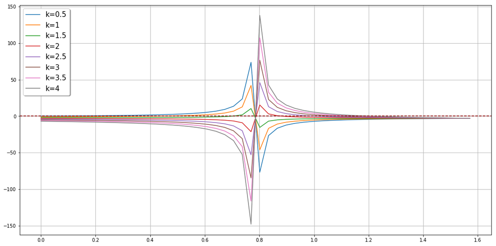

```python
def F(x,k): return (1 + (2 - 2 * k) * math.sin(x))/(math.cos(x) - math.sin(x)) - 2 * k
X = numpy.linspace(0, math.pi/2)

plt.figure(figsize=(18,9))
for k in [0.5, 1, 1.5, 2, 2.5, 3, 3.5, 4]:
    plt.plot(X, [F(x,k) for x in X], label='k='+str(k))

plt.axhline(0, c='darkred', ls='--')
plt.legend(shadow=True, loc=2, fontsize=15)
plt.grid(True)
```

1) Область допустимых значений / Range of admissible values

I. $\cos t - \sin t \neq 0$

$\sin t \neq \cos t$

$\sin^2 t \neq \cos^2 t$

$\sin^2 t \neq 1 - \sin^2 t$

Значение аргумента t - в первой координатной четверти

The value of the argument t is in the first coordinate quarter

$\implies \sin t > 0, \cos t > 0$

$\sin t \neq \frac{\sqrt{2}}{2}$

$\cos \ t = \sin \ t$

$\cos t \neq \frac{\sqrt{2}}{2}$

II. $0 < \sin t < 1; 0 < \cos t < 1; \; \forall t \in$$\bigg( 0; \large{\frac{\pi}{2}} \bigg)$.

III. $\cos^2 t + \sin^2 t = 1$

2) Преобразования уравнения / The transformations of the equation

$\large{\frac{1 \ + \ (2 \ - \ 2 \ * \ k) \ * \ sin \ t}{cos \ t \ - \ sin \ t}}$$\ = 2 * k$

$1 \ + \ (2 \ - \ 2 \ * \ k) \ * \ sin \ t = 2 * k * (\cos t - \sin t)$

$\sin t = k * \cos t - 0.5 \; (*)$

3)

$(*)$ задает на плоскости с координатами $(\cos t, \sin t)$ группу прямых, проходящих через точку (0;-0.5).

Исходное уравнение имеет одно решение, если эти прямые

- пересекают единичную окружность $\cos^2 t + \sin^2 t = 1$,
- точки пересечения лежат в первой координатной четверти $0 < \sin t < 1; 0 < \cos t < 1$.

Для удобства вычислений в данной задаче $\cos t$ отмечен на оси абсцисс, $\sin t $ - на оси ординат.

$(*)$ defines on the plane with coordinates $(\cos t, \sin t)$ the group of lines passing through the point (0; -0.5).

The original equation has one solution if these lines

- intersect the unit circle $\cos^2 t + \sin^2 t = 1$,
- the intersection points lie in the first coordinate quarter $0 < \sin t < 1; 0 < \cos t < 1$.

For convenience of calculations in the given problem $\cos t$ marks on the abscissa, $\sin t$ - on the ordinate axis.

4)

Определим $k$ для случая, когда решений нет: $\cos \ t - \sin \ t = 0$.

Let's define $k$ for the case when there are no solutions: $\cos \ t - \sin \ t = 0$.

$\frac{\sqrt{2}}{2} = k * \frac{\sqrt{2}}{2} - 0.5$

$k = 1 + \frac{\sqrt{2}}{2}$

$\sin \ t = (1 + \frac{\sqrt{2}}{2}) * \cos \ t - 0.5$

5)

Определим $k$ для точки (1;0):

Let's define $k$ for the point (1;0):

$\; 0 = k * 1 - 0.5 \iff k = 0.5$.

$\sin t = 0.5 * \cos t - 0.5$

При любом $k > 0.5$ (за исключением пункта 4) ) прямая вида $(*)$ пересечет единичную окружность в первой координатной четверти.

For any $k > 0.5$ (except for item 4) ), a line of the form $(*)$ intersects the unit circle in the first coordinate quarter.

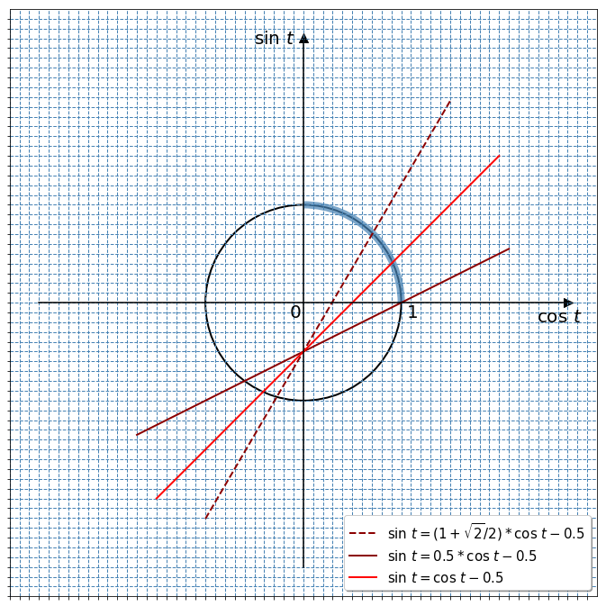

```python
f = plt.figure(figsize=(12,12))
ax = f.add_subplot(1, 1, 1, aspect=1)
ax.grid(c='steelblue', ls='--', lw=1)

circle = pat.Circle((0, 0), 1, lw=2,
                edgecolor='black', facecolor='none')
arc = pat.Arc((0, 0), 2, 2, lw=8, alpha=0.7,
              theta1=0, theta2=90,
              edgecolor='steelblue',
              facecolor='none')
ax.add_artist(circle)
ax.add_artist(arc)

ax.plot([-1,1.5],[(1+math.sqrt(2)/2)*(-1)-0.5,(1+math.sqrt(2)/2)*1.5-0.5],
        ls='--',lw=2,c='darkred',label=r'$\sin \ t = (1 + \sqrt{2}/2) * \cos \ t - 0.5$')
ax.plot([-1.7,2.1],[0.5*(-1.7)-0.5,0.5*2.1-0.5],ls='-',lw=2,c='darkred',
        label=r'$\sin \ t = 0.5 * \cos \ t - 0.5$')
ax.plot([-1.5,2],[-1.5-0.5,2-0.5],ls='-',lw=2,c='red',
        label=r'$\sin \ t = \cos \ t - 0.5$')

ax.axhline(0,0.05,0.95,c='black')
ax.axvline(0,0.05,0.95,c='black')
plt.text(-0.15,-0.15,r'$0$', fontsize=20)
plt.text(1.05,-0.15,r'$1$', fontsize=20)

plt.text(2.38,-0.19,r'$\cos \ t$', fontsize=20)
plt.text(-0.5,2.65,r'$\sin \ t$', fontsize=20)
ax.scatter(0,2.71, marker='^', s=100, c='black')
ax.scatter(2.71,0, marker='>', s=100, c='black')

plt.legend(shadow=True, loc=4, fontsize=15)
plt.xlim(-3,3)
plt.ylim(-3,3)
plt.xticks(numpy.arange(-3, 3, step=0.1), visible=False)
plt.yticks(numpy.arange(-3, 3, step=0.1), visible=False);
```

### Ответ / Answer: $(\frac{1}{2}; 1+\frac{\sqrt{2}}{2}) \cup (1+\frac{\sqrt{2}}{2}; +\infty)$

```python
answer_dictionary[18] ='(1/2;1+√2/2)∪(1+√2/2;+∞)'
```

[figure not shown]

### Задание 19 / Task 19

По кругу в некотором порядке по одному разу написаны числа от 10 до 21. Для каждой из двенадцати пар соседних чисел нашли их наибольший общий делитель.

а) Могло ли получиться так, что все наибольшие общие делители равны 1?

б) Могло ли получится так, что все наибольшие общие делители попарно различны?

в) Какое наибольшее количество попарно различных наибольших общих делителей могло при этом получиться?

On a circle in a certain order, the numbers from 10 to 21 are written once. For each of the twelve pairs of neighboring numbers, their greatest common divisor were found.

a) Could it turn out that all the greatest common divisors are equal to 1?

b) Could it be that all the greatest common divisors are pairwise distinct?

c) What is the largest number of pairwise different greatest common divisors that could be obtained in this case?

а) Да / Yes

$10 = 2 * 5 \to 17 = 17 * 1 \to 12 = 2 * 2 * 3 \to 13 = 13 * 1 \to 18 = 3 * 3 * 2 \to 11 = 11 * 1 \to 14 = 2 * 7 \to $

$\to 15 = 3 * 5 \to 16 = 2 * 2 * 2 * 2 \to 19 = 19 * 1 \to 20 = 2 * 2 * 5 \to 21 = 3 * 7 \to 10 = 2 * 5$

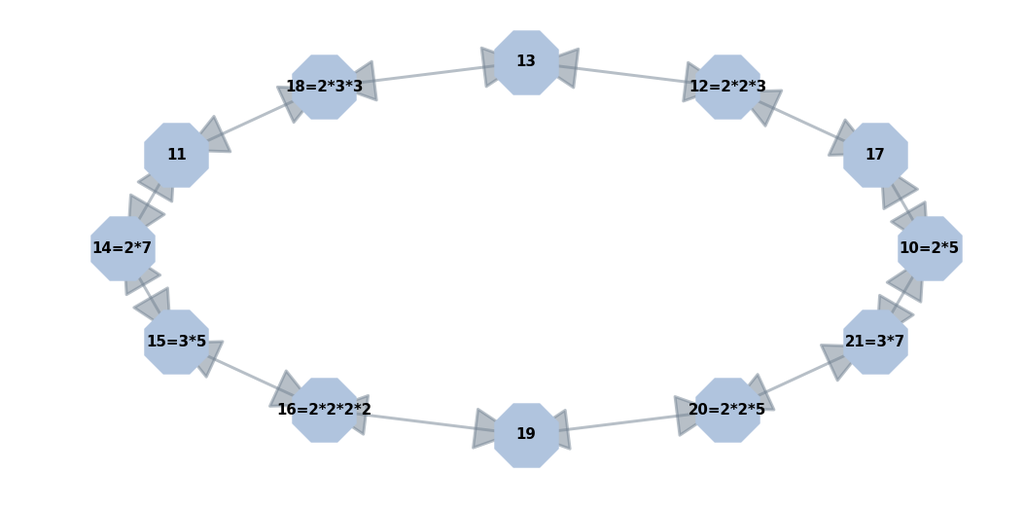

```python
G = nx.MultiDiGraph()
plt.figure(figsize=(18,9))

G.add_edges_from([('10=2*5','17'),('17','12=2*2*3'),('12=2*2*3','13')])
G.add_edges_from([('13','18=2*3*3'),('18=2*3*3','11'),('11','14=2*7')])
G.add_edges_from([('14=2*7','15=3*5'),('15=3*5','16=2*2*2*2'),('16=2*2*2*2','19')])
G.add_edges_from([('19','20=2*2*5'),('20=2*2*5','21=3*7'),('21=3*7','10=2*5')])

pos=nx.shell_layout(G)

nx.draw_networkx_edges(G, pos, width=3, alpha=0.5, edge_color='slategray',
                       arrowsize=100, arrowstyle='<|-|>')
nx.draw_networkx_nodes(G, pos, node_size=5000, node_shape='8', node_color='lightsteelblue')
nx.draw_networkx_labels(G, pos, font_size=15, font_weight='bold')

plt.axis('off')
plt.show()
```

б) Нет / No

12 чисел, записанные по кругу в любом порядке, образуют 12 пар, для каждой из которых определяется наибольший общий делитель (НОД).

Если все 12 НОД различны, то наибольший из них не может быть меньше 12.

Для данного набора чисел $\{10, ..., 21\}$ максимальный НОД равен 10: НОД(10,20) = 10.

Значит, не все НОД попарно различны.

12 numbers, written in a circle in any order, form 12 pairs, for each of which the greatest common divisor (GCD) is defined.

If all 12 GCDs are different, then the largest of them cannot be less than 12.

For the given set of numbers $\{10, ..., 21\}$, the maximum GCD is 10: GCD (10,20) = 10.

Hence, not all GCDs are pairwise different.

в) 8

В наборе $\{10, ..., 21\}$ содержится 4 простых числа $\{11, 13, 17, 19\}$, для них НОД с любыми другими числами всегда равен 1.

Если записать эти 4 простых числа подряд, то потребуется еще по крайней мере два соседних для них элемента из исходного набора: $\{X \to 11 \to 13 \to 17 \to 19 \to Y \}$.

Значит, не меньше 5 пар имеют НОД = 1 и остальные 12 - 5 = 7 НОД могут принимать другие значения.

Всего различных НОД для набора $\{10, ..., 21\}$ не может быть больше 8.

Например:

НОД(10,20)=10, НОД(20,11)=1, НОД(11,13)=1, НОД(13,17)=1, НОД(17,19)=1, НОД(19,18)=1,

НОД(18,12)=6, НОД(12,16)=4, НОД(16,14)=2, НОД(14,21)=7, НОД(21,15)=3, НОД(15,10)=5.

In the set $\{10, ..., 21\}$ there are 4 prime numbers $\{11, 13, 17, 19\}$, for which the GCD with any other numbers is always 1.

If we write these 4 prime numbers together, then at least two more neighboring elements from the original set are required: $\{X \to 11 \to 13 \to 17 \to 19 \to Y \}$.

Hence, at least 5 pairs have GCD = 1 and the remaining 12 - 5 = 7 GCDs can take other values.

For example:

GCD(10,20)=10, GCD(20,11)=1, GCD(11,13)=1, GCD(13,17)=1, GCD(17,19)=1, GCD(19,18)=1,

GOD(18,12)=6, GCD(12,16)=4, GCD(16,14)=2, GCD(14,21)=7, GCD(21,15)=3, GCD(15,10)=5.

### Ответ / Answer: а) да; б) нет; в) 8

```python
answer_dictionary[19] = 'а) да; б) нет; в) 8'
```

## Ответы / Answers

| 1 | 2 | 3 | 4 | 5 | 6 | 7 | 8 | 9 | 10 | 11 | 12 |
| --- | --- | --- | --- | --- | --- | --- | --- | --- | --- | --- | --- |
| 2 | 23 | 9 | 0.96 | -1 | 3 | 3 | 8 | 49 | 33 | 10 | 64 |

| 13 | 14 | 15 | 16 | 17 | 18 | 19 |
| --- | --- | --- | --- | --- | --- | --- |
| а) $\pi - arcctg\large{(\frac{4}{3})}$$\pm 2 * \pi * t, t \in \mathbb{N}$ б) на интервале $[-3 * \pi; -\large{\frac{3*\pi}{2}]}$ корней нет | 36 | $[-1-2\sqrt{6}; 0), (0; 1+2\sqrt{6}]$ | $a * \sqrt{1 + \large{\frac{r}{R}}}$ | 143500 | $(\frac{1}{2}; 1+\frac{\sqrt{2}}{2}) \cup (1+\frac{\sqrt{2}}{2}; +\infty)$ | а) да; б) нет; в) 8 |

```python
answer_dictionary
```

```
{1: '2',
 2: '23',
 3: '9',
 4: '0.96',
 5: '-1',
 6: '3',
 7: '3',
 8: '8',
 9: '49',
 10: '33',
 11: '10',
 12: '64',
 13: 'a) π-arcctg(4/3)±2*π∗t; t∈ℤ; б) на интервале [−3∗π;−3∗π/2] корней нет',
 14: '36',
 15: '[-1-2√6;0), (0;1+2√6]',
 16: 'a*√(1+r/R)',
 17: '143500',
 18: '(1/2;1+√2/2)∪(1+√2/2;+∞)',
 19: 'а) да; б) нет; в) 8'}
```

[figure not shown]